# Group Project 1

Biology 368/664 Bucknell University

Prof. Ken Field

27 Jan 2020

Today, we are working with the telomere distributions of nutritionally restricted Leach’s Storm-petrels. This is one treatment group of an experiment that sought to examine the effects of nutritional restriction and supplementation on telomere distrubtion and subsequent implications on longevity. This is only one of the treatment groups - the restricted birds.

```r
project_data <- read.csv("G1.LHSPele.csv")
#summary(project_data) # no point in showing summary statistics, they are incorrectly calculated
```

Here are some functions created for this project that we will need to use, more on that later.

The data provided gives counts of telomeres (represented by optical density) at different points on a gel (distance given by a ladder). Because individual points have already been summed, we cannot treat the dataset as we might normally do in R. Summary statistics will treat the values for each test as values rather than counts. Therefore, we need to create our own methods for generating summary statistics such as mean and median.

```r
#How to use: assign to a variable (mean1 <- get_mean(DATA$LADDER, DATA$COLUMN)
#Will need to log10 the variable
#Variable will represent the float actual mean
get_mean <- function(ladder, counts) {
  weighted <- (counts * ladder)
  mean <- sum(weighted)/sum(counts)
  return (mean)}
```

The get_median function will likely take a while to run. As mentioned earlier the raw data is actually in a summarized form. Counts are already calculated so this function needs to basically recreate the uncounted data then find the median by division. The get_median function accepts the parameters ladder and counts. The function then iterates through ladder and adds the ladder value to a list n times, where n is the associated number in counts. When the list is complete a variable called median_index is intialized as the length of the list / 2. If the list is odd the modulus of the operation will not be 0. Using that logic we can define two conditions for whether the list length is odd or even. If odd returns the middle index of the list. If even, average of the two middle members in the list.

```r
# How to use: assign to a variable (ie. median1 <- get_median(DATA$LADDER, DATA$COLUMN) )
# May need to log10 the variable later on
# Variable will represent the actual median

get_median <- function(ladder, counts) {
  full <- list()
  for (i in 1:length(ladder)) {
    adjust <- floor(counts[i])
    for (n in 1:adjust) {
      full <- list.append(full, ladder[i])}}

  mod <- (length(full) %% 2)
  median_index <- length(full) / 2
  if (mod != 0) {
    median_index <- median_index + 0.5
    return (as.numeric(as.character(unlist((full[median_index])))))
    }
  else {
    return ((as.numeric(as.character(unlist((full[median_index])))) + as.numeric(as.character(unlist((full[median_index + 1])))))/2)}}
```

The dataset has replicate measurements of each individual. Since we are interested in the means, we will need to calculate the average optical density (analagous to telomere counts) of the individuals at different distances on the ladder. Here we create a new dataframe called “avgs” which contains the average telomere count at each point of the ladder for each individual.

```r
replicates = 3 #Change if not accurate
num = 1
#avgs <- list()

for (i in 3:length(project_data)){ #If data does not begin @ third column change accordingly
  name = (paste0("X", num, sep =""))
  if (i %% replicates == 0) {
    avgs[name] <- (project_data[i] + project_data[i+1] + project_data[i+2]) / replicates #If there are more/less than 3 replicates change accordingly
    num = num + 1}}
avgs <- data.frame(matrix(unlist(avgs), nrow=length(avgs[[1]]), byrow=F)) #Convert data from list to dataframe
avgs$Ladder = project_data$Ladder
```

Exploratory data analysis for this dataset is a little different than it normally would be because counts have already been calculated. To see the distribution of the telomere sizes for a single individual we actually need to plot it. Using stat = “identity” allows us to tell R not to perform it’s default counting methods for the visualization.

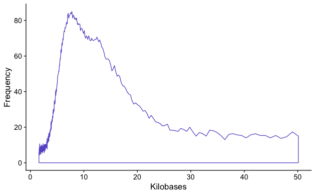

```r
ggplot(avgs) +
  geom_density(aes(x=Ladder, y=X1), fill="", color = "slateblue3", stat="identity", alpha=.3) +
  ylab("Frequency") + xlab("Kilobases") +
  theme_cowplot()
```

As we can see, this data has a strong right skew, which we will soon discuss.

No longer needed use “avgs”

```r
LHSP.concise <- select(LHSP.data, X1:X9)
```

[output not shown]

Most of the descriptive statistics are not accurate due to the nature of the dataset

In order to get a better description of how our data is distributed, we use the describe function below from the package “psych”. This lets us know important descriptive statistics like the mean and median.

```r
describe(avgs)
```

|  | vars | n | mean | sd | median | trimmed | mad | min | max | range | skew | kurtosis | se |
| --- | --- | --- | --- | --- | --- | --- | --- | --- | --- | --- | --- | --- | --- |
| X1 | 1 | 395 | 29.77 | 26.04 | 17.00 | 26.50 | 14.33 | 4.33 | 85.00 | 80.67 | 0.88 | -0.78 | 1.31 |
| X2 | 2 | 395 | 26.55 | 21.98 | 17.67 | 23.78 | 15.32 | 4.00 | 72.33 | 68.33 | 0.85 | -0.76 | 1.11 |
| X3 | 3 | 395 | 29.30 | 25.19 | 16.67 | 26.60 | 14.83 | 2.33 | 79.67 | 77.33 | 0.78 | -0.99 | 1.27 |
| X4 | 4 | 395 | 25.24 | 20.91 | 13.67 | 22.68 | 10.87 | 3.67 | 69.00 | 65.33 | 0.82 | -0.84 | 1.05 |
| X5 | 5 | 395 | 25.24 | 18.57 | 16.33 | 23.39 | 11.86 | 4.00 | 60.67 | 56.67 | 0.76 | -1.01 | 0.93 |
| X6 | 6 | 395 | 19.76 | 13.81 | 13.00 | 18.33 | 9.39 | 3.67 | 48.00 | 44.33 | 0.72 | -1.00 | 0.69 |
| X7 | 7 | 395 | 32.11 | 26.37 | 19.00 | 29.36 | 17.30 | 5.00 | 84.00 | 79.00 | 0.73 | -1.03 | 1.33 |
| X8 | 8 | 395 | 29.90 | 22.01 | 18.67 | 27.94 | 16.31 | 4.00 | 72.00 | 68.00 | 0.63 | -1.16 | 1.11 |
| X9 | 9 | 395 | 29.90 | 26.07 | 15.67 | 26.14 | 12.85 | 3.67 | 91.00 | 87.33 | 1.00 | -0.39 | 1.31 |
| Ladder | 10 | 395 | 8.54 | 10.09 | 4.06 | 6.15 | 2.87 | 1.61 | 50.11 | 48.50 | 2.17 | 4.22 | 0.51 |

Here is a visual representation of the mean and median on our first bird (X1). The mean is shown in blue, and the median is shown in red Typically, telomere data is analyzed by looking at the average telomere length for an individual. However, as we know, with non-normally distrubted data, the average can often be misleading.

For this data, we are plotting frequencies. This means that we can’t simply take the mean of our bird data, because it would give us the mean counts at different spots in the ladder, rather than the mean telomere length itself. If we took the mean of the ladder, that would just give us the middle point of the ladder. In order to properly visualize the mean, we have to account for the fact that this is a frequency distribution, as done below.

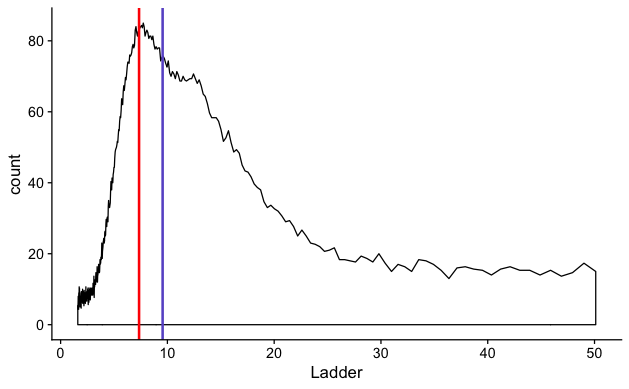

```r
ggplot(avgs) +
  geom_density(aes(x=Ladder, y=X1), fill="", color = "black", stat="identity", alpha=.3) +
  geom_vline(aes(xintercept = get_mean(Ladder, X1)), col='slateblue3', size=1) +
  geom_vline(aes(xintercept = get_median(Ladder, X1)), col='red', size=1) +
  ylab("count") +
  theme_cowplot()
```

As you can see, means and medians give us very different visualizations of the data. Since our data is so right skewed, it doesn’t make sense to rely on the mean as a proper descriptive statistic. Means are important descriptive statistics for normally distributed data; however, in this context with non-normally distributed data, it makes more sense to rely on medians.

In this dataset, if only given one value to represent an entire bird’s telomere length, it is important that the value properly represents the bird. Otherwise, a false sense of health may be attributed to the bird. In this case, the mean is much higher than the median, which may falsely lead readers to believe that the bird has much longer telomeres that it does.

So since this data is skewed, a better representation is the median.

Many statistical tests that can compare means between treatment groups and thus tell us if they are significantly different from each other rely on the fact that the data are normally distributed. In order to use these tests, we must first transform the data to create a normal distribution using log10.

Let’s try to log10 transform the ladder in the avgs dataset for a more normal distribution and plot it. The code used to create the normalized dataset is a simple asignment.

```r
avgs$N_Ladder <- log10(avgs$Ladder)
```

Plot

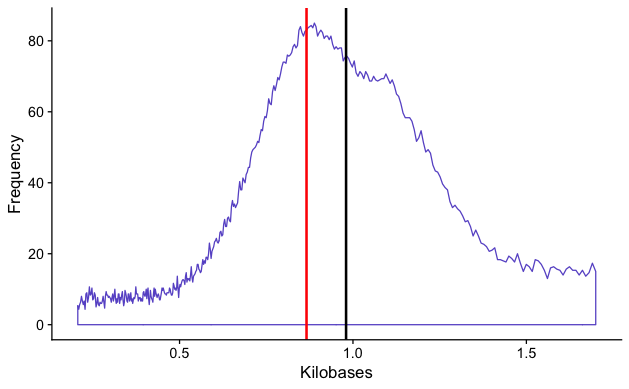

```r
mean1 <- log10(get_mean(avgs$Ladder, avgs$X1))
ggplot(avgs) +
  geom_density(aes(x=N_Ladder, y=X1), color = "slateblue3", stat="identity", alpha=.3) +
  geom_vline(aes(xintercept = mean1), col='black', size=1) +
  geom_vline(aes(xintercept = log10(get_median(Ladder, X1))), col='red', size=1) +
  ylab("Frequency") +
  xlab("Kilobases") +
  theme_cowplot()
```

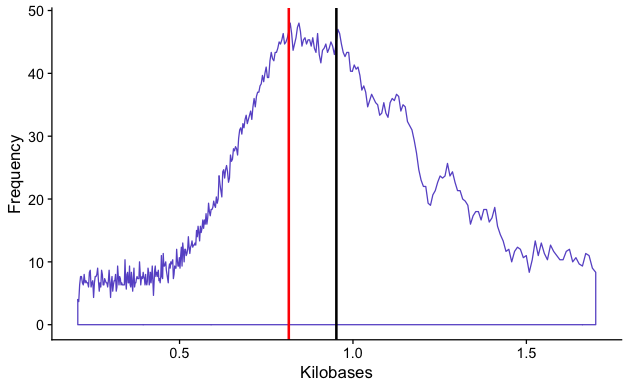

```r
mean2 <- log10(get_mean(avgs$Ladder, avgs$X6))
ggplot(avgs) +
  geom_density(aes(x=N_Ladder, y=X6), color = "slateblue3", stat="identity", alpha=.3) +
  geom_vline(aes(xintercept = mean2), col='black', size=1) +
  geom_vline(aes(xintercept = log10(get_median(Ladder, X6))), col='red', size=1) +
  ylab("Frequency") +
  xlab("Kilobases") +
  theme_cowplot()
```

We can now overlay all nine individuals to see how they compare on this normalized scale. This can give us an idea of how different individuals are from each other within this dataset. It’s important to note these are all individuals from the same treatment group; we expect them to have similar telomere distributions.

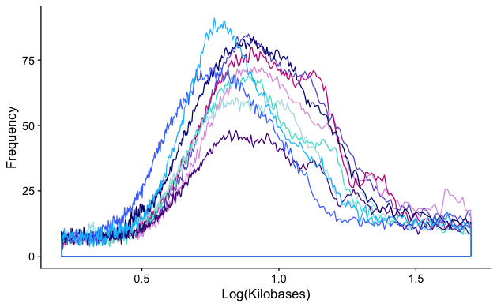

```r
ggplot(avgs) +
  geom_density(aes(x= N_Ladder, y=X1), fill="", color = "slateblue3", stat="identity", alpha=.3) +
  geom_density(aes(x= N_Ladder, y=X2), fill="", color = "plum", stat="identity", alpha=.3) +
  geom_density(aes(x= N_Ladder, y=X3), fill="", color = "mediumvioletred", stat="identity", alpha=.3) +
  geom_density(aes(x= N_Ladder, y=X4), fill="", color = "turquoise", stat="identity", alpha=.3) +
  geom_density(aes(x= N_Ladder, y=X5), fill="", color = "powderblue", stat="identity", alpha=.3) +
  geom_density(aes(x= N_Ladder, y=X6), fill="", color = "purple4", stat="identity", alpha=.3) +
  geom_density(aes(x= N_Ladder, y=X7), fill="", color = "navyblue", stat="identity", alpha=.3) +
  geom_density(aes(x= N_Ladder, y=X8), fill="", color = "royalblue1", stat="identity", alpha=.3) +
  geom_density(aes(x= N_Ladder, y=X9), fill="", color = "deepskyblue", stat="identity", alpha=.3) +
  ylab("Frequency") +
  xlab("Log(Kilobases)") +
  theme_cowplot()
```